# Project 1 611

Jie Chen

2018/9/24

To see a list of all the data sets that are available in my R distribution, I type in `data()` in R console.

```r
data()
```

## Dataset1 **Orange**

After checking out the list of all the datasets in r, I decided to analysis the dataset named Orange. To find out more information about this dataset, I use `?Orange`.

```r
?Orange
```

It says that it includes:

> The Orange data frame has 35 rows and 3 columns of records of the growth of orange trees.

The entire data set is made up of:

> 35 rows and 3 columns

And the original source for the data is:

> This dataset was originally part of package nlme, and that has methods (including for [, as.data.frame, plot and print) for its grouped-data classes.

### Read data into R

```r
 library(tidyverse)
 data(Orange)
```

### Get an idea of what the data looks like

```r
 head(Orange,10)
```

```
##    Tree  age circumference
## 1     1  118            30
## 2     1  484            58
## 3     1  664            87
## 4     1 1004           115
## 5     1 1231           120
## 6     1 1372           142
## 7     1 1582           145
## 8     2  118            33
## 9     2  484            69
## 10    2  664           111
```

```r
 summary(Orange)
```

```
##  Tree       age         circumference
##  3:7   Min.   : 118.0   Min.   : 30.0
##  1:7   1st Qu.: 484.0   1st Qu.: 65.5
##  5:7   Median :1004.0   Median :115.0
##  2:7   Mean   : 922.1   Mean   :115.9
##  4:7   3rd Qu.:1372.0   3rd Qu.:161.5
##        Max.   :1582.0   Max.   :214.0
```

### Produce a figure

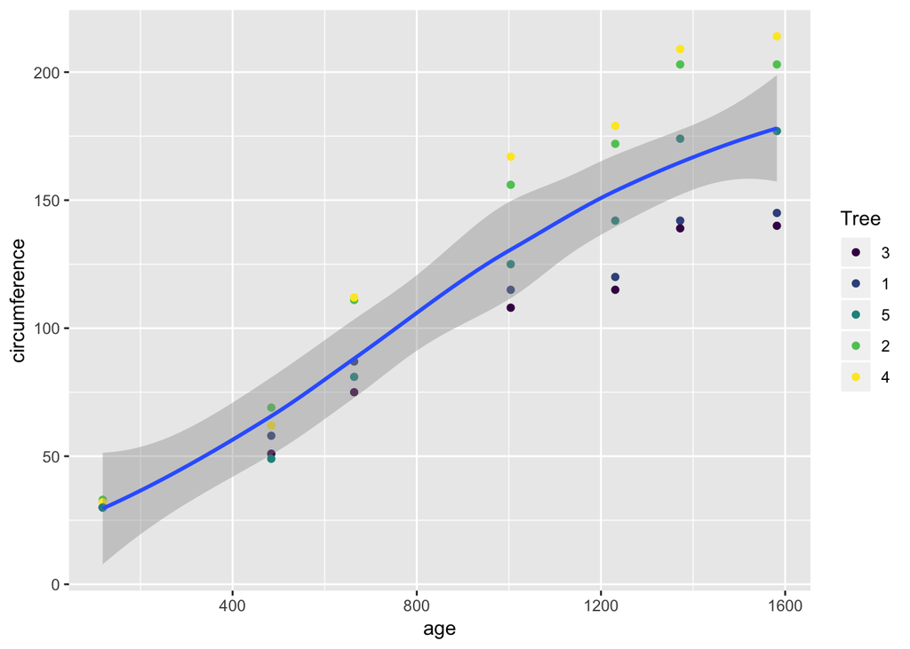

```r
library(ggplot2)
ggplot(data = Orange) +
  geom_point(mapping = aes(x = age, y = circumference, color = Tree))+
  geom_smooth(mapping = aes(x = age, y = circumference))
```

```r
library(dplyr)
Orange %>%
  group_by(Tree) %>%
  summarise(average=mean(circumference))
```

```
## # A tibble: 5 x 2
##   Tree  average
##   <ord>   <dbl>
## 1 3        94
## 2 1        99.6
## 3 5       111.
## 4 2       135.
## 5 4       139.
```

```r
Orange %>%
  group_by(age) %>%
  summarise(average=mean(circumference))
```

```
## # A tibble: 7 x 2
##     age average
##   <dbl>   <dbl>
## 1   118    31
## 2   484    57.8
## 3   664    93.2
## 4  1004   134.
## 5  1231   146.
## 6  1372   173.
## 7  1582   176.
```

### Communicate results

> At a next step, it will be interesting to look at whether the increase in circumference is linear with the age.

## Dataset2 **USArrests**

I chose USArrests as my second dataset. To find out more information about this dataset, I use `?USArrests`.

```r
 ?USArrests
```

It says that it includes:

> This data set contains statistics, in arrests per 100,000 residents for assault, murder, and rape in each of the 50 US states in 1973. Also given is the percent of the population living in urban areas.

The entire data set is made up of:

> 50 observations on 4 variables

And the original source for the data is:

> This dataset was derived from World Almanac and Book of facts 1975(Crime rates) and Statistical Abstracts of the United States 1975(Urban rates).

### Read data into R

```r
data(USArrests)
```

### Get an idea of what the data looks like

```r
 head(USArrests,10)
```

```
##             Murder Assault UrbanPop Rape
## Alabama       13.2     236       58 21.2
## Alaska        10.0     263       48 44.5
## Arizona        8.1     294       80 31.0
## Arkansas       8.8     190       50 19.5
## California     9.0     276       91 40.6
## Colorado       7.9     204       78 38.7
## Connecticut    3.3     110       77 11.1
## Delaware       5.9     238       72 15.8
## Florida       15.4     335       80 31.9
## Georgia       17.4     211       60 25.8
```

```r
 summary(USArrests)
```

```
##      Murder          Assault         UrbanPop          Rape
##  Min.   : 0.800   Min.   : 45.0   Min.   :32.00   Min.   : 7.30
##  1st Qu.: 4.075   1st Qu.:109.0   1st Qu.:54.50   1st Qu.:15.07
##  Median : 7.250   Median :159.0   Median :66.00   Median :20.10
##  Mean   : 7.788   Mean   :170.8   Mean   :65.54   Mean   :21.23
##  3rd Qu.:11.250   3rd Qu.:249.0   3rd Qu.:77.75   3rd Qu.:26.18
##  Max.   :17.400   Max.   :337.0   Max.   :91.00   Max.   :46.00
```

### Produce a figure

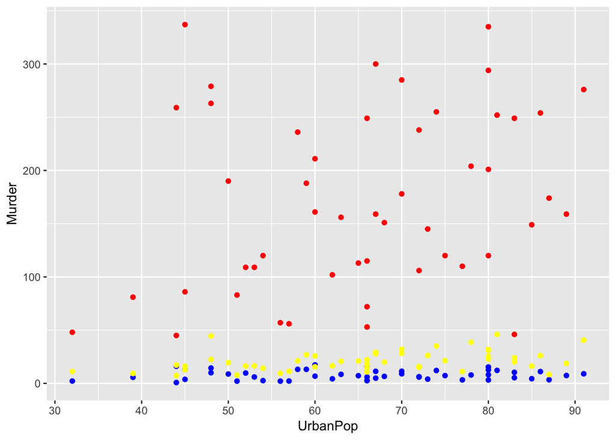

```r
ggplot(data = USArrests)+
  geom_point(mapping = aes(x = UrbanPop, y = Murder),color="blue")+
  geom_point(mapping = aes(x = UrbanPop, y = Assault),color="red")+
  geom_point(mapping = aes(x = UrbanPop, y = Rape),color="yellow")
```

### Communicate results

> At a next step, it will be interesting to look at whether the Murder Assualt and Rape rate has any patterns geographically.

## Dataset3 **sleep**

I chose sleep as my third dataset. To find out more information about this dataset, I use `?sleep`.

```r
 ?sleep
```

It says that it includes:

> This data set shows the effect of two soporific drugs (increase in hours of sleep compared to control) on 10 patients.

The entire data set is made up of:

> 20 observations on 3 variables

And the original source for the data is:

> This dataset was derived from The action of optical isomers: II hyoscines and The probable error of the mean.

### Read data into R

```r
data(sleep)
```

### Get an idea of what the data looks like

```r
 head(sleep,10)
```

```
##    extra group ID
## 1    0.7     1  1
## 2   -1.6     1  2
## 3   -0.2     1  3
## 4   -1.2     1  4
## 5   -0.1     1  5
## 6    3.4     1  6
## 7    3.7     1  7
## 8    0.8     1  8
## 9    0.0     1  9
## 10   2.0     1 10
```

```r
 summary(sleep)
```

```
##      extra        group        ID
##  Min.   :-1.600   1:10   1      :2
##  1st Qu.:-0.025   2:10   2      :2
##  Median : 0.950          3      :2
##  Mean   : 1.540          4      :2
##  3rd Qu.: 3.400          5      :2
##  Max.   : 5.500          6      :2
##                          (Other):8
```

### Produce a figure

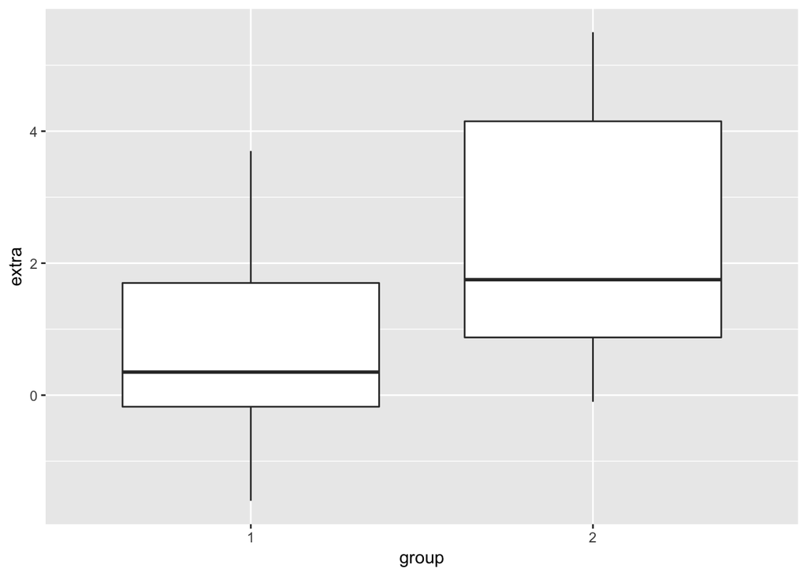

```r
ggplot(data=sleep) +
geom_boxplot(mapping = aes(y = extra, x = group))
```

```r
sleep %>%
  group_by(group) %>%
  summarise(average=mean(extra))
```

```
## # A tibble: 2 x 2
##   group average
##   <fct>   <dbl>
## 1 1        0.75
## 2 2        2.33
```

### Communicate results

> This figure was derived from the “sleep” data set in R. This dataset was derived from The action of optical isomers: II hyoscines and The probable error of the mean.It shows the effect of two soporific drugs (increase in hours of sleep compared to control) on 10 patients. The data are measured on 10 patients, each of the patients are given two soporific drugs. The effect is defined as the numeric increase in hours of sleep. It is the extra variable in our dataset. We can see the average sleep increase hours of group1 is 0.75 hours compared to that of group2 is 2.33 hours. From the boxplot, we can see the average sleep increase hours are not quite normally distributed, it has heavy right tail. That means some of our subjects experience a very large number of increase in sleep. In conclusion, both of them seem to help with sleeping and the drug 2 seems to work much better that the drug1.

> At a next step, it will be interesting to carry out hypothesis testing of whether these two drugs have effect on sleep hours and whether the drug 2 works significantly better than the drug1.

## Dataset4 **ChickWeight**

```r
 ?ChickWeight
```

It says that it includes:

> The ChickWeight data frame has 578 rows and 4 columns from an experiment on the effect of diet on early growth of chicks.

The entire data set is made up of:

> 578 rows and 4 columns

And the original source for the data is:

> This dataset was originally part of package nlme, and that has methods (including for [, as.data.frame, plot and print) for its grouped-data classes.

### Read data into R

```r
data(ChickWeight)
```

### Get an idea of what the data looks like

```r
 head(ChickWeight,10)
```

```
##    weight Time Chick Diet
## 1      42    0     1    1
## 2      51    2     1    1
## 3      59    4     1    1
## 4      64    6     1    1
## 5      76    8     1    1
## 6      93   10     1    1
## 7     106   12     1    1
## 8     125   14     1    1
## 9     149   16     1    1
## 10    171   18     1    1
```

```r
 summary(ChickWeight)
```

```
##      weight           Time           Chick     Diet
##  Min.   : 35.0   Min.   : 0.00   13     : 12   1:220
##  1st Qu.: 63.0   1st Qu.: 4.00   9      : 12   2:120
##  Median :103.0   Median :10.00   20     : 12   3:120
##  Mean   :121.8   Mean   :10.72   10     : 12   4:118
##  3rd Qu.:163.8   3rd Qu.:16.00   17     : 12
##  Max.   :373.0   Max.   :21.00   19     : 12
##                                  (Other):506
```

### Produce a figure

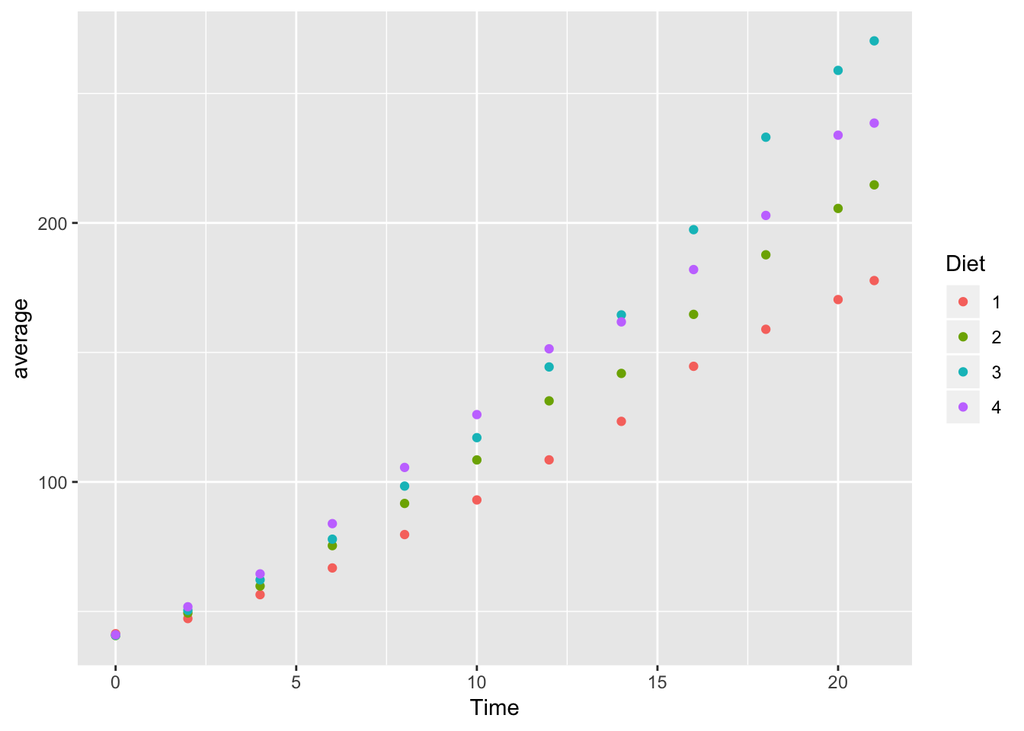

```r
ChickWeight %>%
  group_by(Time,Diet) %>%
  summarise(average=mean(weight)) %>%
  ggplot() +
  geom_point(mapping=aes(x=Time,y=average,color=Diet))
```

```r
ChickWeight %>%
  group_by(Time) %>%
  summarise(average=mean(weight))
```

```
## # A tibble: 12 x 2
##     Time average
##    <dbl>   <dbl>
##  1     0    41.1
##  2     2    49.2
##  3     4    60.0
##  4     6    74.3
##  5     8    91.2
##  6    10   108.
##  7    12   129.
##  8    14   144.
##  9    16   168.
## 10    18   190.
## 11    20   210.
## 12    21   219.
```

```r
ChickWeight %>%
  group_by(Chick) %>%
  summarise(average=mean(weight))
```

```
## # A tibble: 50 x 2
##    Chick average
##    <ord>   <dbl>
##  1 18       37
##  2 16       49.7
##  3 15       60.1
##  4 13       67.8
##  5 9        81.2
##  6 20       78.4
##  7 10       83.1
##  8 8        92
##  9 17       92.5
## 10 19       86.8
## # ... with 40 more rows
```

### Communicate results

> At a next step, it will be interesting to check if there is any loss of follow-up of the chicken weight in our dataset. And we can also perform a hypothesis test to see whether diet 3 works best in increasing chicken weight.